# TD 2 : Modèles de régression en fiabilité

Author

Theau Aguet

Published

March 6, 2026

# 1 Introduction

Ce notebook présente la résolution complète et détaillée des exercices du TD 2, incluant les calculs théoriques de vieillissement accéléré (Arrhenius) et les applications pratiques sur R (Modèle de Cox et Modèle Exponentiel).

# 2 Exercice 1 : Modèle d’Arrhenius (Cartes électroniques)

### 2.0.1 Question 1 : Expression du facteur d’accélération

Le facteur d’accélération $FA$ entre la température normale $\theta_0$ et la température de test $\theta_A$ est défini par :
$$FA = \frac{\lambda(\theta_A)}{\lambda(\theta_0)} = \exp\left( \frac{E_a}{k} \left( \frac{1}{\theta_0} - \frac{1}{\theta_A} \right) \right)$$
Données : $\frac{E_a}{k} = 0.95 \times 10^4$, $\theta_0 = 328^\circ K$.

### 2.0.2 Question 2 : Température de test $\theta_A$

Pour simuler 5 ans (60 mois) en 3 mois, nous ciblons $FA = 20$. $\ln(20) = 9500 \cdot (\frac{1}{328} - \frac{1}{\theta_A}) \implies \theta_A \approx 365.9^\circ K$ (soit $92.7^\circ C$).

### 2.0.3 Question 3 : Fiabilité et MTTF

- **Fiabilité à 3 mois en test** : $\hat{R}_A(3) = \frac{100 - 2}{100} = 0.98$.
- **MTTF en conditions normales** : $\hat{\lambda}_A = -\frac{\ln(0.98)}{3} \approx 0.00673$. $MTTF_0 = FA \cdot \frac{1}{\hat{\lambda}_A} = 20 \cdot 148.59 = \mathbf{2971.8 \text{ mois}}$.

### 2.0.4 Question 4 : Intervalle de confiance à 5 ans

En conditions normales à 5 ans, $\hat{R}_0(60) = \hat{R}_A(3) = 0.98$. $IC_{95\%} = 0.98 \pm 1.96 \sqrt{\frac{0.98 \cdot 0.02}{100}} = [0.9525, 1.00]$.

# 3 Exercice 2 : Système électronique (Weibull & Arrhenius)

### 3.0.1 Question 1 : Loi de Weibull accélérée

Pour une loi de Weibull $W(\beta, \eta)$, sous le modèle d’Arrhenius, le paramètre de forme $\beta$ reste invariant ($\beta_1 = \beta_0$). Seul le paramètre d’échelle $\eta$ est modifié : $\eta_1 = \eta_0 \cdot \exp\left( \alpha \left( \frac{1}{\theta_0} - \frac{1}{\theta_1} \right) \right)$.

### 3.0.2 Question 2 : Estimation à $\theta_1 = 75^\circ C$

**Voir le code R**

```r
library(survival)
library(flexsurv)

data_sys <- read.csv("../data/td_2/sys_arrhenius.csv")
fit_w <- flexsurvreg(Surv(survtime, fail) ~ 1, dist = "weibull", data = data_sys)
fit_w
```

```
Call:
flexsurvreg(formula = Surv(survtime, fail) ~ 1, data = data_sys,
    dist = "weibull")

Estimates:
       est      L95%     U95%     se
shape    1.090    0.753    1.578    0.206
scale  143.235   95.746  214.278   29.436

N = 25,  Events: 20,  Censored: 5
Total time at risk: 2851.839
Log-likelihood = -119.099, df = 2
AIC = 242.1981
```

**Voir le code R**

```r
# Calcul du facteur d'accélération (AF)
alpha <- -15060
theta0 <- 293
theta1 <- 348
AF <- exp(-alpha * (1/theta0 - 1/theta1))
cat("Facteur d'accélération (AF) :", AF)
```

```
Facteur d'accélération (AF) : 3372.654
```

**Analyse :** Le paramètre de forme $\hat{\beta}$ est de **1.09** (proche de 1, suggérant un comportement proche d’une loi exponentielle/taux quasi-constant). Le facteur d’accélération calculé entre $20^\circ C$ et $75^\circ C$ est très élevé, ce qui est typique des modèles thermiques.

### 3.0.3 Question 3 : Distribution à $20^\circ C$

Les paramètres à température habituelle sont :

- $\beta_0 = 1.09$
- $\eta_0 = \hat{\eta}_{scale} \cdot AF = 143.235 \cdot AF$

### 3.0.4 Question 4 : SAV et Marge

Le coût du SAV est proportionnel à $F(t) = 1 - R(t)$. Pour une garantie de 5 ans en conditions normales, le fabricant doit calculer $F_0(5 \text{ ans})$ avec les paramètres $\beta_0, \eta_0$ pour provisionner les remplacements.

# 4 Exercice 3 : Vérin hydraulique (Modèle de Cox)

### 4.0.1 Question 1 : Régression log-linéaire

**Voir le code R**

```r
data_v <- read.csv("../data/td_2/verin.csv")
data_v$temp_inv <- 1 / (data_v$temp + 273.15)

fit_cox <- coxph(Surv(time, fail) ~ temp_inv + press, data = data_v)
summary(fit_cox)
```

```
Call:
coxph(formula = Surv(time, fail) ~ temp_inv + press, data = data_v)

  n= 200, number of events= 175

                coef   exp(coef)    se(coef)      z Pr(>|z|)
temp_inv  -6.335e+02  7.349e-276   3.759e+02 -1.685   0.0919 .
press      3.147e-03   1.003e+00   5.876e-04  5.355 8.56e-08 ***
---
Signif. codes:  0 '***' 0.001 '**' 0.01 '*' 0.05 '.' 0.1 ' ' 1

          exp(coef) exp(-coef) lower .95 upper .95
temp_inv 7.349e-276 1.361e+275     0.000 6.618e+44
press     1.003e+00  9.969e-01     1.002 1.004e+00

Concordance= 0.616  (se = 0.023 )
Likelihood ratio test= 29.4  on 2 df,   p=4e-07
Wald test            = 29.26  on 2 df,   p=4e-07
Score (logrank) test = 30.53  on 2 df,   p=2e-07
```

**Analyse des coefficients :**

- **Pression (`press`)** : Coefficient positif ($3.147 \times 10^{-3}$) avec $p < 0.001$. L’effet est très significatif : une augmentation de la pression accroît le risque de défaillance.
- **Température (`temp_inv`)** : Le coefficient est négatif, ce qui est cohérent (une baisse de $1/\theta$ signifie une hausse de température, augmentant le risque). Toutefois, $p = 0.0919$, l’effet est significatif au seuil de 10% mais pas de 5%.

### 4.0.2 Question 2 : Courbe de fiabilité opérationnelle

**Voir le code R**

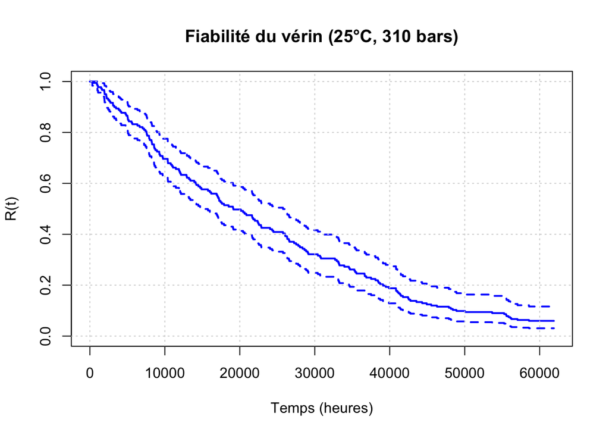

```r
cond_norm <- data.frame(temp_inv = 1/(25 + 273.15), press = 310)
surv_norm <- survfit(fit_cox, newdata = cond_norm)
plot(surv_norm, main="Fiabilité du vérin (25°C, 310 bars)",
     xlab="Temps (heures)", ylab="R(t)", col="blue", lwd=2)
grid()
```

### 4.0.3 Question 3 : Variation du taux de défaillance

Estimation de l’augmentation du taux de défaillance entre les conditions de test ($\theta_0 = 20^\circ C, P_0 = 80$ bars) et opérationnelles ($25^\circ C, 310$ bars).

**Voir le code R**

```r
coefs <- coef(fit_cox)
hr <- exp(coefs[1]*(1/298.15 - 1/293.15) + coefs[2]*(310 - 80))
cat("Le taux de défaillance est multiplié par :", hr)
```

```
Le taux de défaillance est multiplié par : 2.138143
```

**Analyse :** Le passage aux conditions opérationnelles multiplie le taux de défaillance par environ **2.14**. Cette augmentation est principalement pilotée par l’écart important de pression ($+230$ bars), le modèle de Cox quantifiant précisément ce sur-risque par rapport aux tests initiaux.